# RMarkdown

Elementary Statistics

MTH-161D | Spring 2025 | University of Portland

January 22, 2025

# Objectives

- **Introduce R Markdown**
- **Elaborate motivations for learning R in Statistics**
- **Summarize expectations on assignment deliverables**
- **Activity: Modify an RMarkdown document**

# Previously…

[figure not shown]

Basic Parts of R Studio

# R Studio Working Directory

**Where does your saved files automatically go?**

[figure not shown]

The Working Directory

# RMarkdown, an Introduction

**What is RMarkdown?**

- A tool for creating dynamic documents.
- Combines plain text, code, and outputs (e.g., plots, tables).
- RMarkdown is a file with extension “.Rmd”, and when executed, it outputs into HTML, PDF, Word, or Slides.
- It support multiple programming languages.
- It was created for the purpose of automating scientific reports and visualizations.
- It is also professional, clean, and organized.

# RMarkdown for Reproducibility

**Why use RMarkdown?**

- **Dynamic and Flexible Document Creation:** Allows easy updates and ideal for iterative research processes.
- **Integration of Code and Results:** Combine R and other programming languages in the same document. Automatically executes and displays code outputs (e.g., tables, plots).
- **Widely Used in Data Science:** Popular in academia, industry, and reporting. Simplifies workflows for analysis, visualization, and documentation.
- **RMarkdown is required for this course’s homework assignments:** All homework assignments must be completed in RMarkdown and submitted in both `.Rmd` and `.html` formats. *This ensures that your work is detailed, well-organized, and clearly presented.*

# RMarkdown in R Studio

**What does RMarkdown look like in R Studio?**

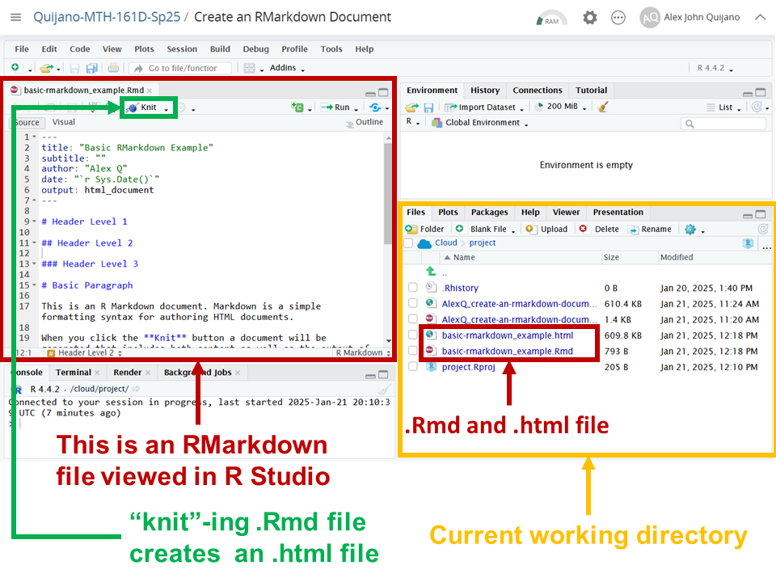

RMarkdown Viewed in R Studio

# Basic Parts of RMarkdown (1/2)

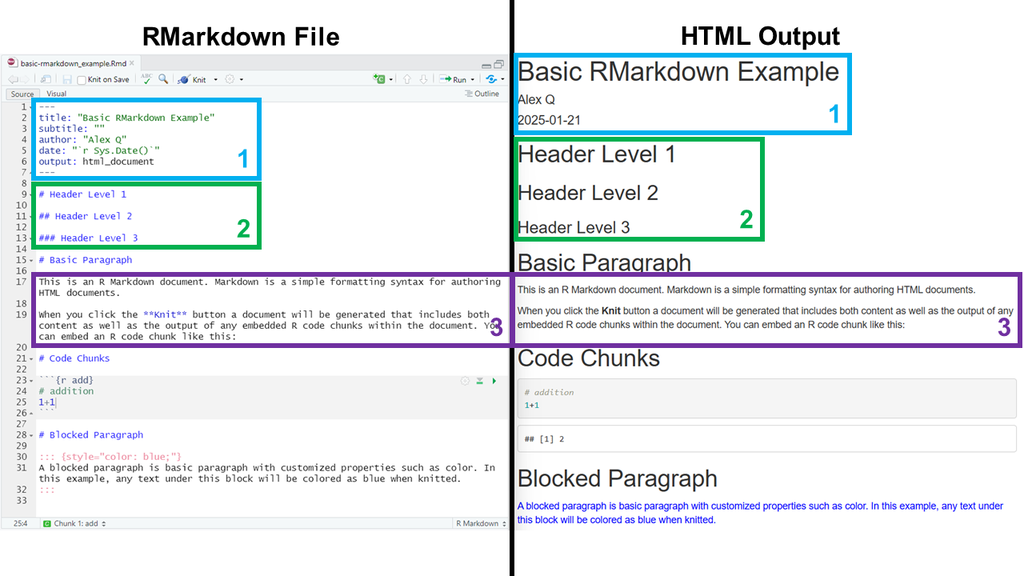

RMarkdown Basic Parts 1, 2, & 3

1. **The YAML header:** It is placed at the very beginning of the file with start and end syntax “`---`”. This header is required and the information that it contains can affect the entire output.
2. **Levels of Headers:** It provides titles to sections.
3. **Basic Paragraph:** Normal text that you can write where a new line means new paragraph.

# Basic Parts of RMarkdown (2/2)

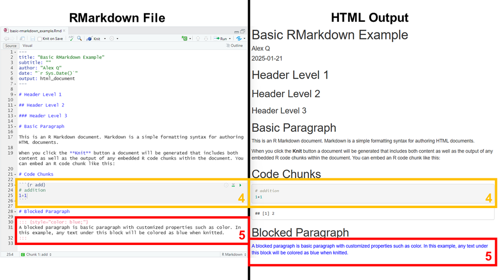

RMarkdown Basic Parts 4 & 5

4. **Code Chunks:** The heart of RMarkdown, where you can run codes and present it and its output clearly with the rest of the document. The start and end syntax is “`` ``` ``”.
5. **Blocked Paragraph:** A special paragraph that allows customization, such as changing the text color of its output.

# Code Chunks in RMarkdown

[figure not shown]

Creating an R Code Chunk

[figure not shown]

Running Code Chunks

# Running R on RMarkdown vs Knitting

[figure not shown]

$\star$ Understanding this difference is key for fixing majority of errors and undesired outputs.

# Transferable Skills

**Why learn any of these things?**

### Statistics

1. Informed decision making
2. Critical thinking
3. Understanding research
4. Critical assessment of reports in research and media
5. Problem-solving

### R

1. Logical reasoning
2. Automating repetitive tasks
3. Programming is an in-demand skill in both industry and academia
4. Learning R is a gateway for more advanced programming languages
5. Learning how to code is a versatile skill and opens up opportunities

# Expectations on Assignment Deliverables

### **Worksheets:**

In-class activities and worksheets must be submitted either physically or through Moodle. Depending on the lesson, submission format will be in physical form, `.pdf`, `.Rmd`, or `.html`.

### **Homework:**

All homework assignments are in RMarkdown and both `.Rmd` and `.html` files must be submitted through Moodle.

### **Assessments:**

Assessments are “quizzes” that will be conducted in class, and must be submitted physically.

$\star$ Your created R Studio space named *Calculator [first name] [first letter of last name]* in Posit Cloud will be used as a calculator for assessments and some worksheets. Homework assignments will have a special R Studio space.

# Tips for Success

**How can I be successful in this class?**

### In-Class

- Show up to class
- Pay attention in class
- Be respectful to your peers
- Carefully read instructions and ask questions
- Know that it’s okay to make mistakes

### Assignments

- Participate in class activities
- Work on worksheet assignments
- Work on your homework diligently
- Even though assessments are open –but no collaboration allowed– you still need to study for it
- Be responsible for your own learning

$\star$ Help hours –walk-in and by appointment– exists!

# Activity: Modify a RMarkdown document

1. Log-in to Posit Cloud and open the R Studio assignment *W 1/22 - Modify a RMarkdown Document*.
2. Make sure you are in the current working directory. Rename the `.Rmd` file by replacing `[name]` with your name using the format `[First name][Last initial]`. Then, open the `.Rmd` file.
3. Change the author in the YAML header.
4. Read the provided instructions.
5. Answer all exercise problems on the designated sections.

# References

Diez, D. M., Barr, C. D., & Çetinkaya-Rundel, M. (2012). *OpenIntro statistics* (4th ed.). OpenIntro. https://www.openintro.org/book/os/